# Supporting Information

Testing the wind disruption and disturbance refugia hypothesis for mountain pine beetle outbreaks (*Dendroctonus ponderosae*). Terrain, stand density and flight-period wind as controls on attack in the Selkirk Mountains of British Columbia

Author

Affiliation

Seamus Murphy

TÜV SÜD

# Table S1

The datasets the study combined, with the spatial and temporal resolution of each.

| Dataset | Source | Spatial | Temporal | Extent |
| --- | --- | --- | --- | --- |
| Red-stage attack | Landsat 5 and 8 Collection 2 Level-2 | 30 m | 1 year and 16 days | 8 years and 47 periods |
| Stand structure | Vegetation Resources Inventory, annual releases | 30 m, rasterised | 1 year | 8 snapshots |
| Terrain | Natural Resources Canada High Resolution Digital Elevation Model | 30 m | static | 61,923 cells |
| Station wind | Environment and Climate Change Canada hourly stations | 9 stations within 150 km | 1 hour | 19,157 hours |
| Terrain-resolved wind | MicroMet terrain adjustment of station wind | 30 m | 1 year and 16 days | 8 years and 47 periods |
| Model tables | Rows joined from the above | 30 m | 1 year and 16 days | 64,000 cell-years and 173,086 cell-periods |

# Table S2

The yearly red-stage maps, with the cells mapped in each year, the share classed as attacked, the ratio of observed to expected joins between neighbouring attacked cells under 999 random permutations, Moran’s I in the first distance class of 60 m, and the range of positive autocorrelation.

| Year | Cells mapped | Attacked (%) | Joins, observed / expected | Moran’s I, 60 m | Range (m) |
| --- | --- | --- | --- | --- | --- |
| 2006 | 61,922 | 10.1 | 4.45 | 0.375 | 3,420 |
| 2007 | 61,923 | 9.9 | 4.92 | 0.411 | 1,380 |
| 2008 | 61,922 | 20.7 | 3.23 | 0.561 | 2,760 |
| 2009 | 61,919 | 12.9 | 4.78 | 0.541 | 1,680 |
| 2010 | 61,761 | 16.5 | 4.21 | 0.619 | 3,240 |
| 2011 | 61,923 | 13.6 | 5.26 | 0.651 | 2,700 |
| 2013 | 61,920 | 16.3 | 4.55 | 0.669 | 2,460 |
| 2014 | 61,923 | 18.3 | 4.14 | 0.680 | 2,520 |

# Table S3

The environmental variables that entered the annual models, grouped by the mechanism each represented. M0 contained host size, shading and landform, M1 added stand density, M2 added terrain exposure to wind, terrain shape and flight-window radiation, and M3 added station wind and the interactions of basal area with the wind shelter index, July wind and flight-window radiation.

| Variable | Mechanism |
| --- | --- |
| Susceptible pine basal area (m² ha⁻¹) | Host size |
| Stand age (years) | Host size |
| Quadratic mean diameter (cm) | Host size |
| Sky view factor | Topographic shading |
| Northness | Topographic shading |
| Elevation (m) | Landform |
| Stand basal area (m² ha⁻¹) | Stand density |
| Wind shelter index | Terrain exposure to wind |
| Topographic position index | Terrain shape |
| Convergence index | Terrain shape |
| Profile curvature | Terrain shape |
| Flight-window direct radiation (kWh/m²) | Flight-window radiation |
| July mean wind (km/h) | Station wind |
| June mean wind (km/h) | Station wind |
| July wind, previous summer (km/h) | Station wind, previous summer |
| June wind, previous summer (km/h) | Station wind, previous summer |
| Surface temperature, previous flight window (°C) | Measured surface temperature, previous summer |
| Ground roughness within the cell at 1 m (m) | Terrain at the scale of single trees |
| Share of the cell facing north at 5 m | Terrain at the scale of single trees |
| Spread of position at 55 m (m) | Terrain at the scale of single trees |
| Crown closure (%) | Stand density |
| Modelled wind at 90 m, previous summer (km/h) | Terrain wind model, previous summer |
| Upslope share of flight hours, previous summer | Terrain wind model, previous summer |
| Consistency of modelled direction, previous summer | Terrain wind model, previous summer |
| Shelter at the modelled wind direction, previous summer | Terrain wind model, previous summer |
| Modelled wind at 30 m, previous summer (km/h) | Terrain wind model, previous summer |
| Modelled wind at 10 m, previous summer (km/h) | Terrain wind model, previous summer |
| Convective lift, previous summer (m/s) | Terrain wind model, previous summer |

# Table S4

Coefficients of the sixteen-day models. E1 had no dependence terms, E2 added the cell’s own state in the previous period and the share attacked around it, and E3 added the same two terms for the same period of the previous year. Estimates are changes in log-odds per standard deviation, with standard errors, the number of cells and the AUC of each model; intercepts and geomorphon classes are not shown. * p ≤ 0.05, ** p ≤ 0.01, *** p ≤ 0.001, **** p ≤ 0.0001.

| Model | Term | Estimate | SE | n | AUC |
| --- | --- | --- | --- | --- | --- |
| E1 | Elevation (m) | +0.393**** | 0.008 | 146,390 | 0.676 |
| E1 | Susceptible pine basal area (m² ha⁻¹) | +0.202**** | 0.007 | 146,390 | 0.676 |
| E1 | Standing volume (m³ ha⁻¹) | +0.106**** | 0.010 | 146,390 | 0.676 |
| E1 | Live stems (n/ha) | -0.104**** | 0.007 | 146,390 | 0.676 |
| E1 | Quadratic mean diameter (cm) | -0.078**** | 0.008 | 146,390 | 0.676 |
| E1 | Crown closure (%) | +0.098**** | 0.008 | 146,390 | 0.676 |
| E1 | Terrain ruggedness index | -0.073**** | 0.008 | 146,390 | 0.676 |
| E1 | Vector ruggedness measure | -0.017* | 0.007 | 146,390 | 0.676 |
| E1 | Topographic position index | +0.030*** | 0.009 | 146,390 | 0.676 |
| E1 | Mid-slope position | -0.075**** | 0.006 | 146,390 | 0.676 |
| E1 | Valley depth (m) | -0.032**** | 0.008 | 146,390 | 0.676 |
| E1 | Profile curvature | -0.002 | 0.006 | 146,390 | 0.676 |
| E1 | Growing-season direct radiation (kWh/m²) | -0.092**** | 0.009 | 146,390 | 0.676 |
| E1 | Flight-window direct radiation (kWh/m²) | +0.234**** | 0.013 | 146,390 | 0.676 |
| E1 | Windward-leeward index | +0.163**** | 0.011 | 146,390 | 0.676 |
| E1 | Flight-hour wind (km/h) | +0.014* | 0.006 | 146,390 | 0.676 |
| E1 | Live stems x Flight-hour wind | -0.012* | 0.006 | 146,390 | 0.676 |
| E1 | Standing volume x Flight-hour wind | -0.003 | 0.006 | 146,390 | 0.676 |
| E1 all hours | Elevation (m) | +0.394**** | 0.008 | 146,390 | 0.677 |
| E1 all hours | Susceptible pine basal area (m² ha⁻¹) | +0.209**** | 0.007 | 146,390 | 0.677 |
| E1 all hours | Standing volume (m³ ha⁻¹) | +0.099**** | 0.010 | 146,390 | 0.677 |
| E1 all hours | Live stems (n/ha) | -0.093**** | 0.007 | 146,390 | 0.677 |
| E1 all hours | Quadratic mean diameter (cm) | -0.067**** | 0.008 | 146,390 | 0.677 |
| E1 all hours | Crown closure (%) | +0.101**** | 0.008 | 146,390 | 0.677 |
| E1 all hours | Terrain ruggedness index | -0.076**** | 0.008 | 146,390 | 0.677 |
| E1 all hours | Vector ruggedness measure | -0.019** | 0.007 | 146,390 | 0.677 |
| E1 all hours | Topographic position index | +0.025** | 0.009 | 146,390 | 0.677 |
| E1 all hours | Mid-slope position | -0.077**** | 0.006 | 146,390 | 0.677 |
| E1 all hours | Valley depth (m) | -0.028*** | 0.008 | 146,390 | 0.677 |
| E1 all hours | Profile curvature | -0.001 | 0.006 | 146,390 | 0.677 |

[output cut: 272 more lines]

# Table S5

Every sixteen-day period used, with its start date, the cells the imagery saw and the share classed as attacked. Periods in which the imagery saw less than a tenth of the perimeter were dropped.

| Year | Period | Start | Cells seen | Attacked (%) |
| --- | --- | --- | --- | --- |
| 2006 | 1 | 2006-05-01 | 48,329 | 5.6 |
| 2006 | 2 | 2006-05-17 | 16,703 | 8.4 |
| 2006 | 3 | 2006-06-02 | 9,426 | 26.0 |
| 2006 | 4 | 2006-06-18 | 18,568 | 11.2 |
| 2006 | 5 | 2006-07-04 | 55,107 | 17.3 |
| 2006 | 6 | 2006-07-20 | 41,218 | 9.4 |
| 2006 | 7 | 2006-08-05 | 46,263 | 5.7 |
| 2006 | 8 | 2006-08-21 | 60,102 | 12.4 |
| 2007 | 1 | 2007-05-01 | 50,919 | 9.9 |
| 2007 | 5 | 2007-07-04 | 56,511 | 13.3 |
| 2007 | 6 | 2007-07-20 | 41,218 | 18.3 |
| 2007 | 7 | 2007-08-05 | 61,246 | 11.3 |
| 2007 | 8 | 2007-08-21 | 35,655 | 12.6 |
| 2008 | 3 | 2008-06-02 | 9,932 | 57.4 |
| 2008 | 5 | 2008-07-04 | 15,069 | 9.8 |
| 2008 | 6 | 2008-07-20 | 6,293 | 7.8 |
| 2008 | 7 | 2008-08-05 | 53,059 | 8.6 |
| 2008 | 8 | 2008-08-21 | 9,279 | 9.5 |
| 2009 | 1 | 2009-05-01 | 17,062 | 10.9 |
| 2009 | 2 | 2009-05-17 | 37,124 | 15.2 |
| 2009 | 4 | 2009-06-18 | 18,566 | 12.3 |
| 2009 | 5 | 2009-07-04 | 56,511 | 16.2 |
| 2009 | 6 | 2009-07-20 | 35,156 | 10.5 |
| 2009 | 7 | 2009-08-05 | 61,246 | 11.0 |
| 2009 | 8 | 2009-08-21 | 35,147 | 39.0 |
| 2010 | 1 | 2010-05-01 | 13,007 | 10.2 |
| 2010 | 4 | 2010-06-18 | 9,106 | 37.4 |
| 2010 | 5 | 2010-07-04 | 17,158 | 23.1 |
| 2010 | 7 | 2010-08-05 | 59,387 | 11.5 |
| 2010 | 8 | 2010-08-21 | 8,618 | 26.3 |
| 2011 | 2 | 2011-05-17 | 14,102 | 5.7 |
| 2011 | 4 | 2011-06-18 | 8,606 | 18.9 |
| 2011 | 5 | 2011-07-04 | 53,179 | 23.7 |
| 2011 | 6 | 2011-07-20 | 32,384 | 15.4 |
| 2011 | 7 | 2011-08-05 | 61,246 | 13.8 |
| 2011 | 8 | 2011-08-21 | 60,102 | 17.8 |
| 2013 | 1 | 2013-05-01 | 29,392 | 8.5 |
| 2013 | 4 | 2013-06-18 | 12,760 | 33.1 |
| 2013 | 5 | 2013-07-04 | 45,303 | 22.6 |
| 2013 | 6 | 2013-07-20 | 39,873 | 25.8 |
| 2013 | 7 | 2013-08-05 | 43,605 | 38.8 |
| 2013 | 8 | 2013-08-21 | 59,452 | 34.2 |
| 2014 | 1 | 2014-05-01 | 53,035 | 11.1 |
| 2014 | 2 | 2014-05-17 | 9,048 | 7.4 |
| 2014 | 4 | 2014-06-18 | 18,286 | 29.2 |
| 2014 | 5 | 2014-07-04 | 44,890 | 20.2 |
| 2014 | 7 | 2014-08-05 | 56,249 | 22.9 |

# Methods S1

The wind component of the MicroMet model of Liston & Elder (2006) is seven equations, implemented directly from the source paper with its equation numbers given below.

Terrain slope $\beta$ and slope azimuth $\xi$ came from the elevation model, equations 12 and 13 of Liston & Elder (2006). Curvature $\Omega_c$ is a cell’s elevation minus the mean of the two opposite cells one curvature length scale away, taken on four direction lines and averaged, their equation 14, and the length scale was estimated as the first lag at which elevation autocorrelation fell below 0.5, which was 600 m here. Assigning $\theta$ to wind bearing, slope in the wind direction was computed as follows

$$\Omega_s = \beta \cos(\theta - \xi) \tag{1}$$

with $\Omega_s$ and $\Omega_c$ each scaled to $[-0.5,\,0.5]$. The terrain weighting factor applied to the observed speed $W$ was derived using

$$W_w = 1 + \gamma_s \Omega_s + \gamma_c \Omega_c, \qquad \gamma_s = \gamma_c = 0.5 \tag{2}$$

This provided the basis for calculation of the terrain-modified speed using

$$W_t = W_w W \tag{3}$$

and a diversion of wind direction computed as

$$\theta_d = -\tfrac{1}{2}\, \Omega_s \sin\!\left[2(\xi - \theta)\right]. \tag{4}$$

By Equation 2, $W_w$ depends on direction and not on speed, so it was computed once for each of 16 wind direction sectors of 22.5 degrees, the sixteen points of the compass, and each hourly observation was multiplied by the surface for its own sector, so that nothing was averaged before the terrain acted on it, and over all sectors $W_w$ ran from 0.66 to 1.32.

# Figure S1

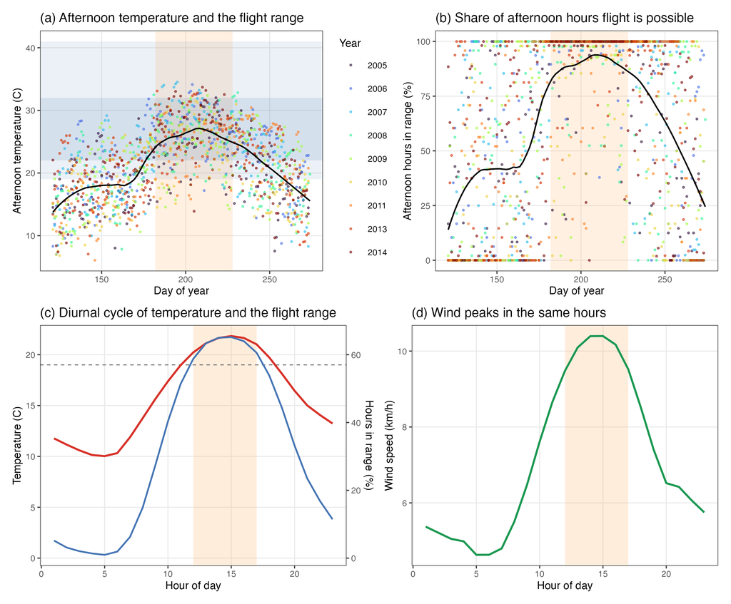

The flight window against the landscape’s own climate, from hourly Environment and Climate Change Canada station records for May to September of the study years. The shaded band marked the window, 1 July to 15 August, taken from the bionomics and not fitted to these data. (a) Mean afternoon temperature by day of year, with the 19 to 41 degrees C flight range and the 22 to 32 degrees C peak band marked. (b) The share of afternoon hours inside the flight range, day by day. (c) Mean temperature and the share of all hours inside the flight range, by hour, with the 12:00 to 17:00 restriction shaded. (d) Mean wind speed by hour on the same axis, showing that the hours in which the beetle could fly were also the windiest of the day.

## References

Liston, G. E., & Elder, K. (2006). A meteorological distribution system for high-resolution terrestrial modeling (MicroMet). *Journal of Hydrometeorology*, *7*(2), 217–234. https://doi.org/10.1175/JHM486.1